# Homework_03

Mustafa Kamal Shahadat

2023-03-18

### Load required packages

```r
library(plyr) # Note: load 'plyr' before 'dplyr'
library(dplyr)
library(tidyverse)
library(car)
```

```r
library(carData)
library(nortest)
library(outliers)
library(report)
library(RColorBrewer)
library(ggstatsplot)
library(gtsummary)
library(ggExtra)
library(gridExtra)
library(xtable)
library(flextable)
#install.packages("tidyverse", dependencies = TRUE)
#install.packages("car", dependencies = TRUE)
#install.packages("nortest", dependencies = TRUE)
#install.packages("outliers", dependencies = TRUE)
#install.packages("plyr", dependencies = TRUE)
#install.packages("report", dependencies = TRUE)
#install.packages("RColorBrewer", dependencies = TRUE)
#install.packages("ggstatsplot", dependencies = TRUE)
#install.packages("gtsummary", dependencies = TRUE)
#install.packages("ggExtra", dependencies = TRUE)
#install.packages("gridExtra", dependencies = TRUE)
#install.packages("xtable", dependencies = TRUE)
#install.packages("flextable", dependencies = TRUE)
```

```r
# Load data files
df<- read_csv("bd_arsenic_data.csv")
df.gh<- read_csv("bd_green_house.csv")
```

### Tasks

1. Check the data structure with str() function

```r
str(df)
```

```
## spc_tbl_ [263 × 31] (S3: spec_tbl_df/tbl_df/tbl/data.frame)
##  $ ID        : num [1:263] 1 2 3 4 5 6 7 8 9 10 ...
##  $ Longitude : num [1:263] 89.1 89.1 89.1 89.1 89.1 ...
##  $ Latitude  : num [1:263] 22.8 22.8 22.7 22.8 22.7 ...
##  $ GAs       : num [1:263] 0.432 0.395 0.26 0.367 0.424 0.537 0.462 0.432 0.544 0.3 ...
##  $ StAs      : num [1:263] 19.9 12.3 6.6 18.7 20.3 27.1 23.5 19.1 28.1 11.8 ...
##  $ WAs       : num [1:263] 0.059 0.059 0.079 0.122 0.072 0.042 0.075 0.064 0.065 0.06 ...
##  $ WP        : num [1:263] 0.761 1.194 1.317 1.545 0.966 ...
##  $ WFe       : num [1:263] 3.44 4.93 9.7 8.58 4.78 6.95 7.81 8.14 8.99 8.82 ...
##  $ WEc       : num [1:263] 1.03 1.07 1.4 0.83 1.42 1.82 1.71 1.74 1.57 1.42 ...
##  $ WpH       : num [1:263] 7.03 7.06 6.84 6.85 6.95 6.89 6.86 6.98 6.82 6.84 ...
##  $ WMg       : num [1:263] 33.9 34.1 40.5 28.4 43.4 43.2 50.1 51.5 48.2 28.7 ...
##  $ WNa       : num [1:263] 69.4 74.6 89.4 22.8 93 ...
##  $ WCa       : num [1:263] 99.1 94.3 133.9 103.8 130.5 ...
##  $ WK        : num [1:263] 5.3 5.7 6 4 5.3 6.5 5.9 6.4 6.5 3.7 ...
##  $ WS        : num [1:263] 2.94 2.83 2.31 1.01 2.51 ...
##  $ SAs       : num [1:263] 29.1 45.1 23.2 23.8 26 25.6 26.3 31.6 19.2 12.4 ...
##  $ SPAs      : num [1:263] 9.89 10.7 5.87 6.03 6.63 ...
##  $ SAoAs     : num [1:263] 13.3 21.9 12.3 12.6 13.8 ...
##  $ SAoFe     : num [1:263] 2500 2670 2160 2500 2060 2500 2520 2140 2150 2160 ...
##  $ SpH       : num [1:263] 7.74 7.87 8.03 8.07 7.81 7.77 7.66 7.89 8 7.92 ...
##  $ SEc       : num [1:263] 1.13 1.02 1.26 1.07 1.35 ...
##  $ SOC       : num [1:263] 1.66 1.26 1.36 1.61 1.26 1.74 1.71 1.69 1.41 1.39 ...
##  $ SAND      : num [1:263] 16.3 11.1 12.3 12.7 12.1 16.7 16.8 13.7 12.6 13.1 ...
##  $ SILT      : num [1:263] 44.8 48.7 46.4 43.6 50.9 43.6 43.4 40.8 44.9 44.5 ...
##  $ CLAY      : num [1:263] 38.9 40.2 41.3 43.7 37.1 39.8 39.8 45.5 42.4 42.4 ...
##  $ SP        : num [1:263] 13.8 15.3 15.5 16.3 14.2 ...
##  $ ELEV      : num [1:263] 3 5 4 3 5 2 2 3 3 3 ...
##  $ Year_Irrig: num [1:263] 14 20 10 8 10 9 8 10 8 2 ...
##  $ DIS_STW   : num [1:263] 5 6 5 8 5 5 10 8 10 8 ...
##  $ Variety   : chr [1:263] "BR28" "Minikate" "IET" "IET" ...
##  $ Land_type : chr [1:263] "MHL" "MHL" "MHL" "MHL" ...
##  - attr(*, "spec")=
##   .. cols(
##   ..   ID = col_double(),
##   ..   Longitude = col_double(),
##   ..   Latitude = col_double(),
##   ..   GAs = col_double(),
##   ..   StAs = col_double(),
##   ..   WAs = col_double(),
```

[output cut: 12 more lines]

```
##   ..   SAoFe = col_double(),
##   ..   SpH = col_double(),
##   ..   SEc = col_double(),
##   ..   SOC = col_double(),
##   ..   SAND = col_double(),
##   ..   SILT = col_double(),
##   ..   CLAY = col_double(),
##   ..   SP = col_double(),
##   ..   ELEV = col_double(),
##   ..   Year_Irrig = col_double(),
##   ..   DIS_STW = col_double(),
##   ..   Variety = col_character(),
##   ..   Land_type = col_character()
##   .. )
##  - attr(*, "problems")=<externalptr>
```

```r
str(df.gh)
```

```
## spc_tbl_ [42 × 13] (S3: spec_tbl_df/tbl_df/tbl/data.frame)
##  $ ID       : num [1:42] 1 2 3 4 5 6 7 8 9 10 ...
##  $ Treatment: chr [1:42] "Low As" "Low As" "Low As" "Low As" ...
##  $ Variety  : chr [1:42] "BR01" "BR01" "BR01" "BR06" ...
##  $ REP      : num [1:42] 1 2 3 1 2 3 1 2 3 1 ...
##  $ PH       : num [1:42] 84 112 102 118 115 ...
##  $ TN       : num [1:42] 28.3 34 27.7 23.3 16.7 19 21.7 25.3 23 19.7 ...
##  $ PN       : num [1:42] 27.7 30 24 19.7 12.3 15.3 19.3 21 19 14.7 ...
##  $ GW       : num [1:42] 35.7 58.1 44.6 46.4 19.9 35.9 56.2 49.2 48.6 36.6 ...
##  $ ster     : num [1:42] 20.5 14.8 5.8 20.3 32.3 14.9 6.1 9.2 4.2 12.1 ...
##  $ DTM      : num [1:42] 126 119 120 119 120 ...
##  $ SW       : num [1:42] 28.4 36.7 32.9 40 28.2 42.3 35.4 60.6 69.8 57.3 ...
##  $ GAs      : num [1:42] 0.762 0.722 0.858 1.053 1.13 ...
##  $ STAs     : num [1:42] 14.6 10.8 12.7 18.2 13.7 ...
##  - attr(*, "spec")=
##   .. cols(
##   ..   ID = col_double(),
##   ..   Treatment = col_character(),
##   ..   Variety = col_character(),
##   ..   REP = col_double(),
##   ..   PH = col_double(),
##   ..   TN = col_double(),
##   ..   PN = col_double(),
##   ..   GW = col_double(),
##   ..   ster = col_double(),
##   ..   DTM = col_double(),
##   ..   SW = col_double(),
##   ..   GAs = col_double(),
##   ..   STAs = col_double()
##   .. )
##  - attr(*, "problems")=<externalptr>
```

2. Check missing values if any.

```r
sum(is.na(df))
```

```
## [1] 0
```

```r
sum(is.na(df.gh))
```

```
## [1] 0
```

3. Create a summary statistics table with these variables: GAs, WAs, SAs, SPAs, SAoAs, SAoFe from arsenic data.

```r
summary(df$GAs)
```

```
##    Min. 1st Qu.  Median    Mean 3rd Qu.    Max.
##  0.0940  0.2450  0.3130  0.3257  0.3850  0.8450
```

```r
summary(df$WAs)
```

```
##    Min. 1st Qu.  Median    Mean 3rd Qu.    Max.
##  0.0110  0.0745  0.1190  0.1299  0.1750  0.4580
```

```r
summary(df$SAs)
```

```
##    Min. 1st Qu.  Median    Mean 3rd Qu.    Max.
##    4.70   12.70   17.20   17.89   22.05   51.80
```

```r
summary(df$SPAs)
```

```
##    Min. 1st Qu.  Median    Mean 3rd Qu.    Max.
##   0.779   2.880   4.060   4.411   5.600  14.804
```

```r
summary(df$SAoAs)
```

```
##    Min. 1st Qu.  Median    Mean 3rd Qu.    Max.
##   1.390   6.195   9.800   9.798  12.573  27.869
```

```r
summary(df$SAoFe)
```

```
##    Min. 1st Qu.  Median    Mean 3rd Qu.    Max.
##    1000    2280    2570    2597    2845    4940
```

```r
summary_stat <- df %>%
  # First select  numerical columns
  dplyr::select(GAs, WAs, SAs, SPAs, SAoAs, SAoFe) %>%
  # get summary statistics
  dplyr::summarise_all(funs(Min = round(min(.),2),
                      Q25 = round(quantile(., 0.25),2),
                      Median = round(median(.),2),
                      Q75 = round(quantile(., 0.75),2),
                      Max = round(max(.),2),
                      Mean = round(mean(.),2),
                      SD = round(sd(.),3))) %>%
                # create a nice looking table
                tidyr::pivot_longer(everything(),
                            names_sep = "_",
                            names_to = c( "variable", ".value"))
# Load library
library(flextable)
# Create a table
flextable::flextable(summary_stat, theme_fun = theme_booktabs)
```

| variable | Min | Q25 | Median | Q75 | Max | Mean | SD |
| --- | --- | --- | --- | --- | --- | --- | --- |
| GAs | 0.09 | 0.24 | 0.31 | 0.38 | 0.84 | 0.33 | 0.120 |
| WAs | 0.01 | 0.07 | 0.12 | 0.17 | 0.46 | 0.13 | 0.079 |
| SAs | 4.70 | 12.70 | 17.20 | 22.05 | 51.80 | 17.89 | 7.388 |
| SPAs | 0.78 | 2.88 | 4.06 | 5.60 | 14.80 | 4.41 | 2.236 |
| SAoAs | 1.39 | 6.20 | 9.80 | 12.57 | 27.87 | 9.80 | 4.568 |
| SAoFe | 1,000.00 | 2,280.00 | 2,570.00 | 2,845.00 | 4,940.00 | 2,597.00 | 626.341 |

5. Create a histogram, density plot QQ-plot of Soil As (SAs) with ggplot2 package.

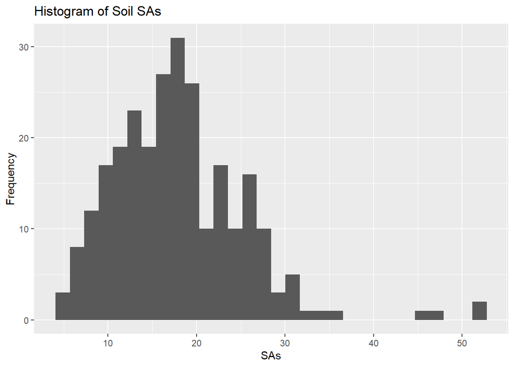

```r
ggplot(df, aes(SAs)) +
  geom_histogram()+
  # X-axis title
  xlab("SAs") +
  # y-axis title
  ylab("Frequency")+
  # plot title
  ggtitle("Histogram of Soil SAs")
```

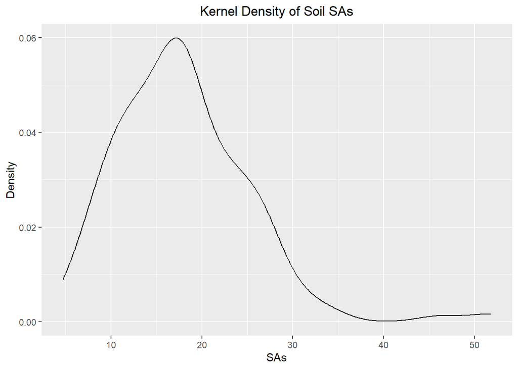

```r
ggplot(df, aes(SAs)) +
  geom_density()+
  # x-axis title
  xlab("SAs") +
  # y-axis title
  ylab("Density")+
  # plot title
  ggtitle("Kernel Density of Soil SAs")+
    theme(
    # Center the plot title
    plot.title = element_text(hjust = 0.5))
```

[figure not shown]

```r
ggplot(df, aes(sample = SAs)) +
  stat_qq() +
  stat_qq_line() +
  # x-axis title
  xlab("Theoretical Quantiles)") +
  # y-axis title
  ylab("Sample Quantiles")+
  # plot title
  ggtitle("Q-Q plot of Soil SOC from a Normal Distribution")+
    theme(
    # Center the plot title
    plot.title = element_text(hjust = 0.5),
    # x-axis title font size
    axis.title.x = element_text(size = 14),
    # y-axis title font size
    axis.title.y = element_text(size = 14),)
```

6. Do normality test of WAs, SAs, GAs and measure the Skewness and Kurtosis of these variables.

```r
shapiro.test(df$WAs)
```

```
##
##  Shapiro-Wilk normality test
##
## data:  df$WAs
## W = 0.94389, p-value = 1.738e-08
```

```r
shapiro.test(df$SAs)
```

```
##
##  Shapiro-Wilk normality test
##
## data:  df$SAs
## W = 0.93076, p-value = 9.513e-10
```

```r
shapiro.test(df$GAs)
```

```
##
##  Shapiro-Wilk normality test
##
## data:  df$GAs
## W = 0.94069, p-value = 8.276e-09
```

```r
library(moments)
moments::skewness(df$WAs)
```

```
## [1] 0.9768018
```

```r
moments::kurtosis(df$WAs)
```

```
## [1] 4.450374
```

```r
moments::skewness(df$SAs)
```

```
## [1] 1.211611
```

```r
moments::kurtosis(df$SAs)
```

```
## [1] 6.399313
```

```r
moments::skewness(df$GAs)
```

```
## [1] 1.113887
```

```r
moments::kurtosis(df$GAs)
```

```
## [1] 5.684813
```

7. Create two scatter plots with ggplot2: i) WAs vs GAs and ii) SAs vs GAs, and show them side by side (p1+p2)

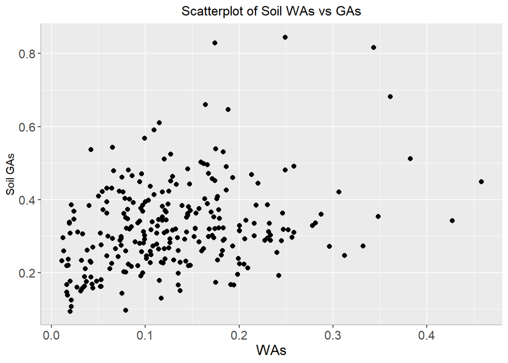

```r
p1<- ggplot(df, aes(x=WAs, y=GAs)) +
  geom_point(size=2) +
  # add plot title
  ggtitle("Scatterplot of Soil WAs vs GAs") +
   theme(
    # center the plot title
    plot.title = element_text(hjust = 0.5),
    axis.line = element_line(colour = "gray"),
    # axis title font size
    axis.title.x = element_text(size = 14),
    # X and  axis font size
    axis.text.y=element_text(size=12,vjust = 0.5, hjust=0.5),
    axis.text.x = element_text(size=12))+
     xlab("WAs") +
     ylab("Soil GAs")
p1
```

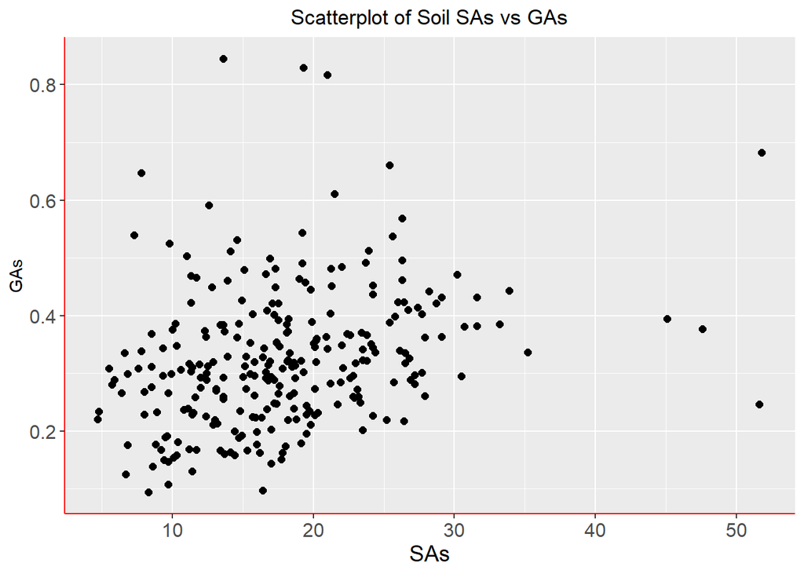

```r
p2<- ggplot(df, aes(x=SAs, y=GAs)) +
  geom_point(size=2) +
  # add plot title
  ggtitle("Scatterplot of Soil SAs vs GAs") +
   theme(
    # center the plot title
    plot.title = element_text(hjust = 0.5),
    axis.line = element_line(colour = "red"),
    # axis title font size
    axis.title.x = element_text(size = 14),
    # X and  axis font size
    axis.text.y=element_text(size=12,vjust = 0.5, hjust=0.5),
    axis.text.x = element_text(size=12))+
     xlab("SAs") +
     ylab("GAs")
p2
```

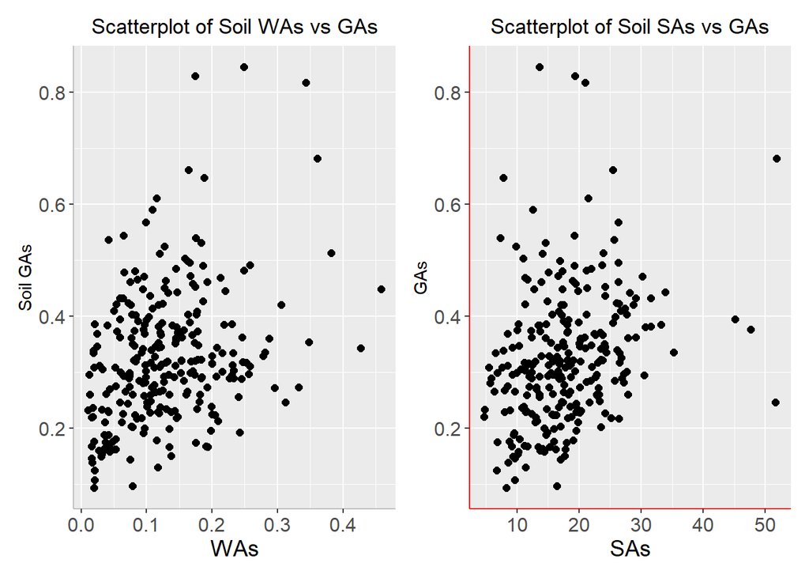

```r
p1+p2
```

8. Create a 3D bubble plot

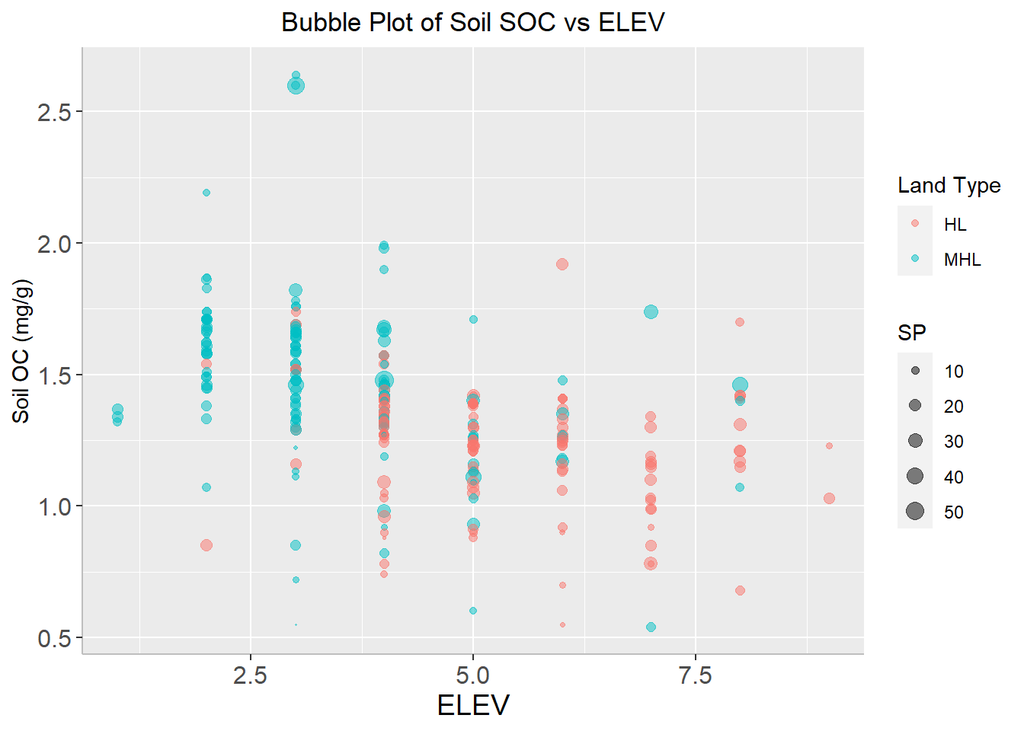

```r
#conflicts_prefer(plyr::mutate)
#conflicts_prefer(dplyr::arrange)
df %>%
  arrange(desc(SOC)) %>%
  mutate(Land_type = factor(Land_type)) %>%
  ggplot(aes(x=ELEV, y=SOC, size = SP, color=Land_type)) +
    geom_point(alpha=0.5) +
    scale_size(range = c(.2, 4), name="SP")+
     guides(color = guide_legend(title = "Land_type"))+
  ggtitle("Bubble Plot of Soil SOC vs ELEV") +
   theme(
    # center the plot title
    plot.title = element_text(hjust = 0.5),
    axis.line = element_line(colour = "gray"),
    # axis title font size
    axis.title.x = element_text(size = 14),
    # X and  axis font size
    axis.text.y=element_text(size=12,vjust = 0.5, hjust=0.5),
    axis.text.x = element_text(size=12))+
      # add legend tittle
  guides(color = guide_legend(title = "Land Type")) +
  xlab("ELEV") +
  ylab("Soil OC (mg/g)")
```

9. Create a correlation matrix table showing significant levels. Use GAs, StAs, WAs, SAs, SPAs, SAoAs, ans SAoFe variables.

```r
#library(Hmisc)
# create a data frame for correlation analysis
df.cor<-df %>% dplyr::select(GAs, StAs, WAs, SAs, SPAs, SAoAs, SAoFe)
# correlation matrix
cor.mat<-Hmisc::rcorr(as.matrix(df.cor, type="pearson"))
cor.mat
```

```
##         GAs  StAs   WAs   SAs  SPAs SAoAs SAoFe
## GAs    1.00  0.53  0.33  0.29  0.31  0.22 -0.22
## StAs   0.53  1.00  0.22  0.31  0.33  0.22 -0.10
## WAs    0.33  0.22  1.00  0.24  0.28  0.27 -0.10
## SAs    0.29  0.31  0.24  1.00  0.89  0.89 -0.11
## SPAs   0.31  0.33  0.28  0.89  1.00  0.85 -0.08
## SAoAs  0.22  0.22  0.27  0.89  0.85  1.00 -0.02
## SAoFe -0.22 -0.10 -0.10 -0.11 -0.08 -0.02  1.00
##
## n= 263
##
##
## P
##       GAs    StAs   WAs    SAs    SPAs   SAoAs  SAoFe
## GAs          0.0000 0.0000 0.0000 0.0000 0.0004 0.0003
## StAs  0.0000        0.0004 0.0000 0.0000 0.0003 0.0993
## WAs   0.0000 0.0004        0.0001 0.0000 0.0000 0.1059
## SAs   0.0000 0.0000 0.0001        0.0000 0.0000 0.0787
## SPAs  0.0000 0.0000 0.0000 0.0000        0.0000 0.1714
## SAoAs 0.0004 0.0003 0.0000 0.0000 0.0000        0.7247
## SAoFe 0.0003 0.0993 0.1059 0.0787 0.1714 0.7247
```

```r
# install.packages("xtable")
library(xtable)

cor_table <- function(x){
  require(Hmisc)
  x <- as.matrix(x)
  R <- rcorr(x)$r
  p <- rcorr(x)$P

  ## define notions for significance levels; spacing is important.
  mystars <- ifelse(p < .001, "***", ifelse(p < .01, "** ", ifelse(p < .05, "* ", " ")))

  ## trunctuate the matrix that holds the correlations to three decimal
  R <- format(round(cbind(rep(-1.11, ncol(x)), R), 3))[,-1]

  ## build a new matrix that includes the correlations with their apropriate stars
  Rnew <- matrix(paste(R, mystars, sep=""), ncol=ncol(x))
  diag(Rnew) <- paste(diag(R), " ", sep="")
  rownames(Rnew) <- colnames(x)
  colnames(Rnew) <- paste(colnames(x), "", sep="")

  ## remove upper triangle
  Rnew <- as.matrix(Rnew)
  Rnew[upper.tri(Rnew, diag = TRUE)] <- ""
  Rnew <- as.data.frame(Rnew)

  ## remove last column and return the matrix (which is now a data frame)
  Rnew <- cbind(Rnew[1:length(Rnew)-1])
  return(Rnew)
}
```

```r
cor_table(df.cor)
```

```
##             GAs      StAs       WAs       SAs      SPAs   SAoAs
## GAs
## StAs   0.525***
## WAs    0.326***  0.217***
## SAs    0.287***  0.314***  0.235***
## SPAs   0.306***  0.327***  0.281***  0.888***
## SAoAs  0.217***  0.219***  0.275***  0.889***  0.850***
## SAoFe -0.222***   -0.102    -0.100    -0.109    -0.085  -0.022
```

10. Create a Correlation matrix plot of above correlation analysis.

```r
# Load GGally library
library(GGally)
```

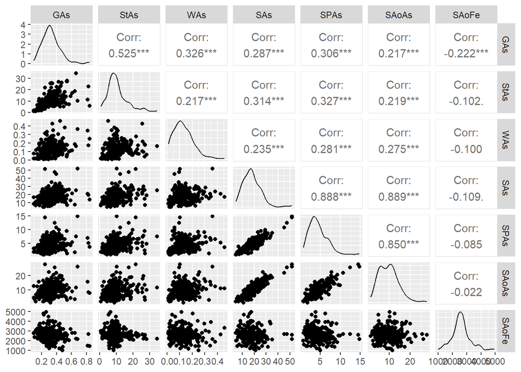

```r
GGally::ggpairs(df.cor)
```

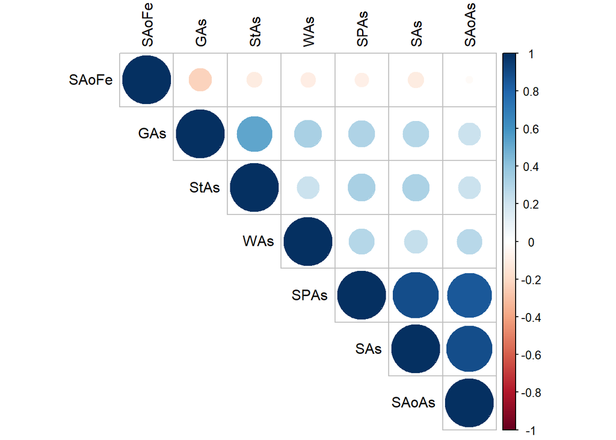

```r
# Load corrplot library
library(corrplot)
# Create plot
corrplot(cor.mat$r,
         type="upper",
         order="hclust",
         cex.lab = 0.5,
         tl.col = "black",
         p.mat = cor.mat$p,
         sig.level = 0.05, insig = "blank")
```

11. Use ggplot2 to create two barplots with error bar: i) GAs and Treatment II) GAs and varieties. And show them side by side. Use bd_green_house data

```r
# Standard error
SE <- function(x){
  sd(x)/sqrt(length(x))
}
```

```r
# Load library
#library(plyr)
# Get summary statistics
summarise_GAs1<-ddply(df.gh,~Treatment, summarise,
                Mean= round(mean(GAs), 3),
                Median=round (median(GAs), 3),
                Min= round (min(GAs),3),
                Max= round (max(GAs),3),
                SD= round(sd(GAs), 3),
                SE= round (SE(GAs), 3))
# Load library
library(flextable)
# Create a table
flextable::flextable(summarise_GAs1, theme_fun = theme_booktabs)
```

| Treatment | Mean | Median | Min | Max | SD | SE |
| --- | --- | --- | --- | --- | --- | --- |
| High As | 1.817 | 1.872 | 1.396 | 2.493 | 0.337 | 0.073 |
| Low As | 0.945 | 0.946 | 0.605 | 1.359 | 0.219 | 0.048 |

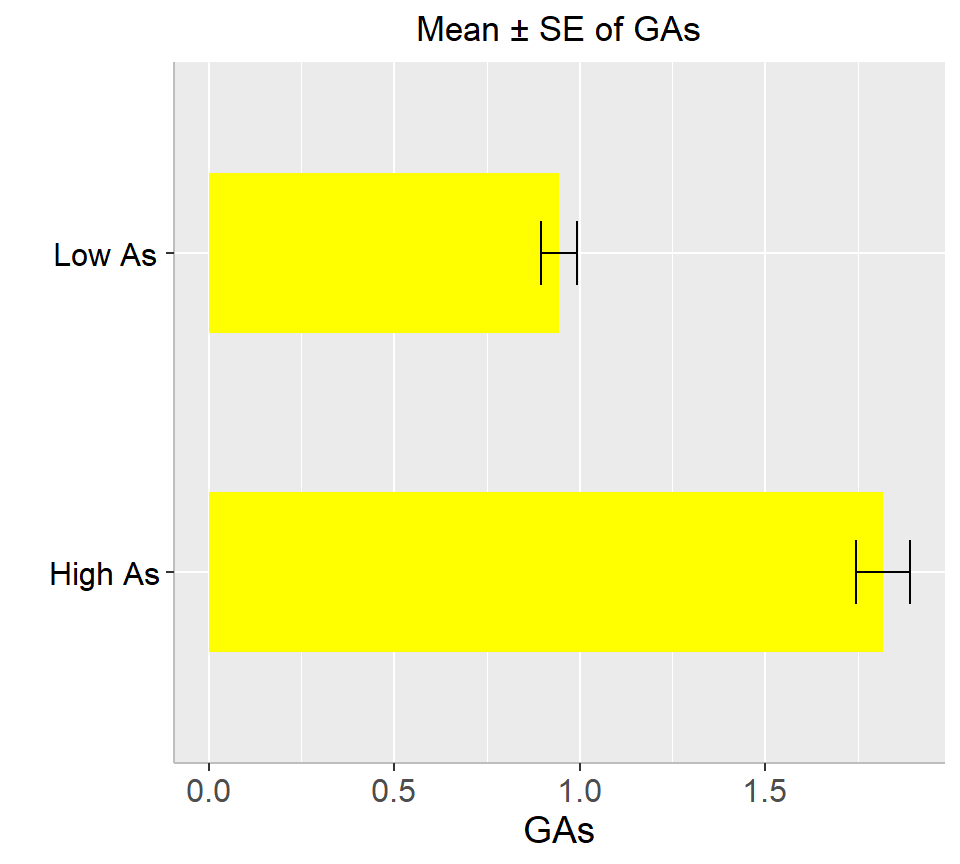

```r
p3 = ggplot(summarise_GAs1, aes(x=Treatment, y=Mean)) +
  geom_bar(stat="identity", position=position_dodge(),width=0.5, fill="yellow") +
  geom_errorbar(aes(ymin=Mean-SE, ymax=Mean+SE), width=.2,
   position=position_dodge(.9))+
  # add y-axis title and x-axis title leave blank
  labs(y="GAs", x = "")+
  # add plot title
  ggtitle("Mean ± SE of GAs")+
  coord_flip()+
  # customize plot themes
  theme(
        axis.line = element_line(colour = "gray"),
        # plot title position at center
        plot.title = element_text(hjust = 0.5),
        # axis title font size
        axis.title.x = element_text(size = 14),
        # X and  axis font size
        axis.text.y=element_text(size=12,vjust = 0.5, hjust=0.5, colour='black'),
        axis.text.x = element_text(size=12))
p3
```

```r
# Get summary statistics
summarise_GAs2<-ddply(df.gh,~Variety, summarise,
                Mean= round(mean(GAs), 3),
                Median=round (median(GAs), 3),
                Min= round (min(GAs),3),
                Max= round (max(GAs),3),
                SD= round(sd(GAs), 3),
                SE= round (SE(GAs), 3))
# Load library
library(flextable)
# Create a table
flextable::flextable(summarise_GAs2, theme_fun = theme_booktabs)
```

| Variety | Mean | Median | Min | Max | SD | SE |
| --- | --- | --- | --- | --- | --- | --- |
| BR01 | 1.156 | 1.170 | 0.722 | 1.564 | 0.414 | 0.169 |
| BR06 | 1.242 | 1.263 | 1.011 | 1.451 | 0.199 | 0.081 |
| BR28 | 1.266 | 1.245 | 0.893 | 1.698 | 0.361 | 0.147 |
| BR35 | 1.901 | 1.904 | 1.290 | 2.493 | 0.620 | 0.253 |
| BR36 | 1.413 | 1.407 | 0.832 | 1.997 | 0.576 | 0.235 |
| Jefferson | 1.270 | 1.251 | 0.605 | 2.007 | 0.719 | 0.294 |
| Kaybonnet | 1.419 | 1.394 | 0.946 | 1.889 | 0.473 | 0.193 |

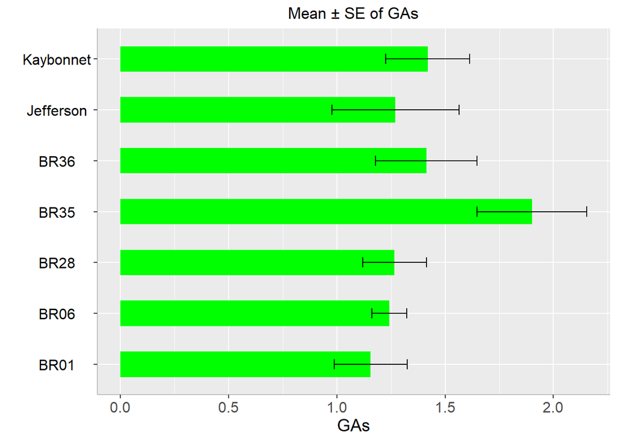

```r
p4 = ggplot(summarise_GAs2, aes(x=Variety, y=Mean)) +
  geom_bar(stat="identity", position=position_dodge(),width=0.5, fill="green") +
  geom_errorbar(aes(ymin=Mean-SE, ymax=Mean+SE), width=.2,
   position=position_dodge(.9))+
  # add y-axis title and x-axis title leave blank
  labs(y="GAs", x = "")+
  # add plot title
  ggtitle("Mean ± SE of GAs")+
  coord_flip()+
  # customize plot themes
  theme(
        axis.line = element_line(colour = "gray"),
        # plot title position at center
        plot.title = element_text(hjust = 0.5),
        # axis title font size
        axis.title.x = element_text(size = 14),
        # X and  axis font size
        axis.text.y=element_text(size=12,vjust = 0.5, hjust=0.5, colour='black'),
        axis.text.x = element_text(size=12))

p4
```

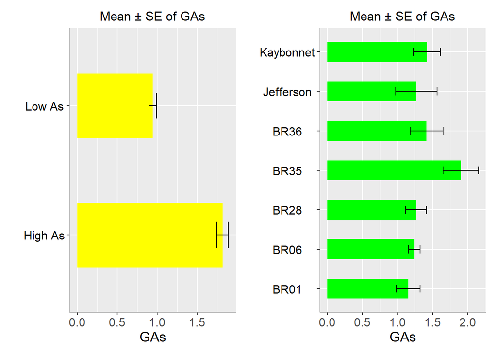

```r
p3+p4
```

12. Do t-test and show whether there is any significant difference in As concentration in rice (GAs) between low and high As soil treatments.

```r
# Create two dataframes
T1 <- df.gh %>% dplyr::select(Treatment, GAs) %>%
         filter(Treatment == "High As")

T2 <- df.gh %>% dplyr::select(Treatment, GAs) %>%
         filter(Treatment == "Low As")

# Two-Sample T-test
t.test(x=T1$GAs,
       y=T2$GAs,
       paired = TRUE,
       alternative = "greater")
```

```
##
##  Paired t-test
##
## data:  T1$GAs and T2$GAs
## t = 12.835, df = 20, p-value = 2.052e-11
## alternative hypothesis: true mean difference is greater than 0
## 95 percent confidence interval:
##  0.754535      Inf
## sample estimates:
## mean difference
##       0.8716667
```

13. Do one-way and two-way ANOVA show main effect of treatment and rice variety and their interaction on rice grain As and explain the results.

```r
anova.one=aov (GAs ~Treatment, data = df.gh) # analysis variance
anova (anova.one)
```

```
## Analysis of Variance Table
##
## Response: GAs
##           Df Sum Sq Mean Sq F value   Pr(>F)
## Treatment  1 7.9779  7.9779  98.913 2.26e-12 ***
## Residuals 40 3.2262  0.0807
## ---
## Signif. codes:  0 '***' 0.001 '**' 0.01 '*' 0.05 '.' 0.1 ' ' 1
```

```r
# Load library
# library(report)
report(anova.one)
```

```
## The ANOVA (formula: GAs ~ Treatment) suggests that:
##
##   - The main effect of Treatment is statistically significant and large (F(1, 40)
## = 98.91, p < .001; Eta2 = 0.71, 95% CI [0.58, 1.00])
##
## Effect sizes were labelled following Field's (2013) recommendations.
```

Two-way ANOVA

```r
anova.two =aov (GAs ~Treatment + Variety+ Treatment:Variety, data = df.gh)
anova (anova.two)
```

```
## Analysis of Variance Table
##
## Response: GAs
##                   Df Sum Sq Mean Sq  F value    Pr(>F)
## Treatment          1 7.9779  7.9779 2668.990 < 2.2e-16 ***
## Variety            6 2.2091  0.3682  123.172 < 2.2e-16 ***
## Treatment:Variety  6 0.9335  0.1556   52.049 6.668e-14 ***
## Residuals         28 0.0837  0.0030
## ---
## Signif. codes:  0 '***' 0.001 '**' 0.01 '*' 0.05 '.' 0.1 ' ' 1
```

```r
# Load library
# library(report)
report(anova.two)
```

```
## The ANOVA (formula: GAs ~ Treatment + Variety + Treatment:Variety) suggests
## that:
##
##   - The main effect of Treatment is statistically significant and large (F(1, 28)
## = 2668.99, p < .001; Eta2 (partial) = 0.99, 95% CI [0.98, 1.00])
##   - The main effect of Variety is statistically significant and large (F(6, 28) =
## 123.17, p < .001; Eta2 (partial) = 0.96, 95% CI [0.94, 1.00])
##   - The interaction between Treatment and Variety is statistically significant
## and large (F(6, 28) = 52.05, p < .001; Eta2 (partial) = 0.92, 95% CI [0.86,
## 1.00])
##
## Effect sizes were labelled following Field's (2013) recommendations.
```

14. Do multiple comparison of two main effect.

```r
tukey <- TukeyHSD(anova.one)
tukey
```

```
##   Tukey multiple comparisons of means
##     95% family-wise confidence level
##
## Fit: aov(formula = GAs ~ Treatment, data = df.gh)
##
## $Treatment
##                      diff       lwr        upr p adj
## Low As-High As -0.8716667 -1.048802 -0.6945309     0
```

```r
pairwise.t.test(df.gh$GAs, df.gh$Treatment,
                 p.adjust.method = "bonferroni",
                 paired=FALSE)
```

```
##
##  Pairwise comparisons using t tests with pooled SD
##
## data:  df.gh$GAs and df.gh$Treatment
##
##        High As
## Low As 2.3e-12
##
## P value adjustment method: bonferroni
```

```r
pairwise.t.test(df.gh$GAs, df.gh$Variety,
                 p.adjust.method = "bonferroni",
                 paired=FALSE)
```

```
##
##  Pairwise comparisons using t tests with pooled SD
##
## data:  df.gh$GAs and df.gh$Variety
##
##           BR01 BR06 BR28 BR35 BR36 Jefferson
## BR06      1.00 -    -    -    -    -
## BR28      1.00 1.00 -    -    -    -
## BR35      0.33 0.65 0.78 -    -    -
## BR36      1.00 1.00 1.00 1.00 -    -
## Jefferson 1.00 1.00 1.00 0.80 1.00 -
## Kaybonnet 1.00 1.00 1.00 1.00 1.00 1.00
##
## P value adjustment method: bonferroni
```

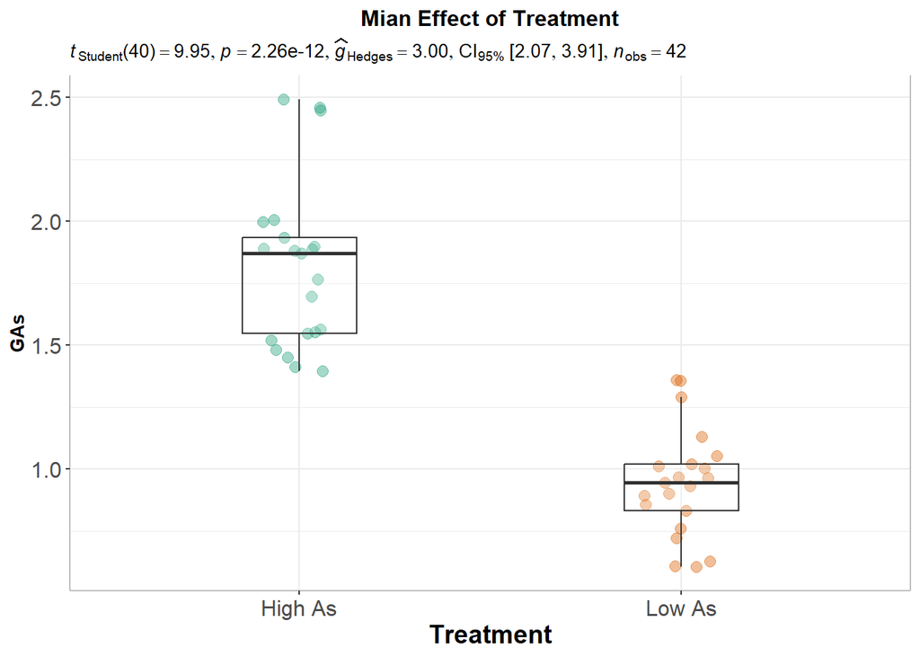

```r
# Load library
#library(ggstatsplot)

p1<-ggbetweenstats(
  data = df.gh,
  x = Treatment,
  y = GAs,
  ylab = "GAs",
  type = "parametric", # ANOVA or Kruskal-Wallis
  var.equal = TRUE, # ANOVA or Welch ANOVA
  plot.type = "box",
  pairwise.comparisons = TRUE,
  pairwise.display = "significant",
  centrality.plotting = FALSE,
  bf.message = FALSE
)+
# add plot title
ggtitle("Mian Effect of Treatment") +
   theme(
    # center the plot title
    plot.title = element_text(hjust = 0.5),
    axis.line = element_line(colour = "gray"),
    # axis title font size
    axis.title.x = element_text(size = 14),
    # X and  axis font size
    axis.text.y=element_text(size=12,vjust = 0.5, hjust=0.5),
    axis.text.x = element_text(size=12))
print(p1)
```

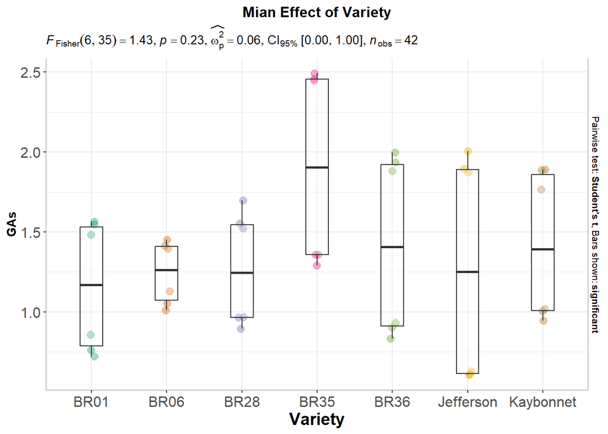

```r
# Load library
library(ggstatsplot)

p2<-ggbetweenstats(
  data = df.gh,
  x = Variety,
  y = GAs,
  ylab = "GAs",
  type = "parametric", # ANOVA or Kruskal-Wallis
  var.equal = TRUE, # ANOVA or Welch ANOVA
  plot.type = "box",
  pairwise.comparisons = TRUE,
  pairwise.display = "significant",
  centrality.plotting = FALSE,
  bf.message = FALSE
)+
# add plot title
ggtitle("Mian Effect of Variety") +
   theme(
    # center the plot title
    plot.title = element_text(hjust = 0.5),
    axis.line = element_line(colour = "gray"),
    # axis title font size
    axis.title.x = element_text(size = 14),
    # X and  axis font size
    axis.text.y=element_text(size=12,vjust = 0.5, hjust=0.5),
    axis.text.x = element_text(size=12))
print(p2)
```

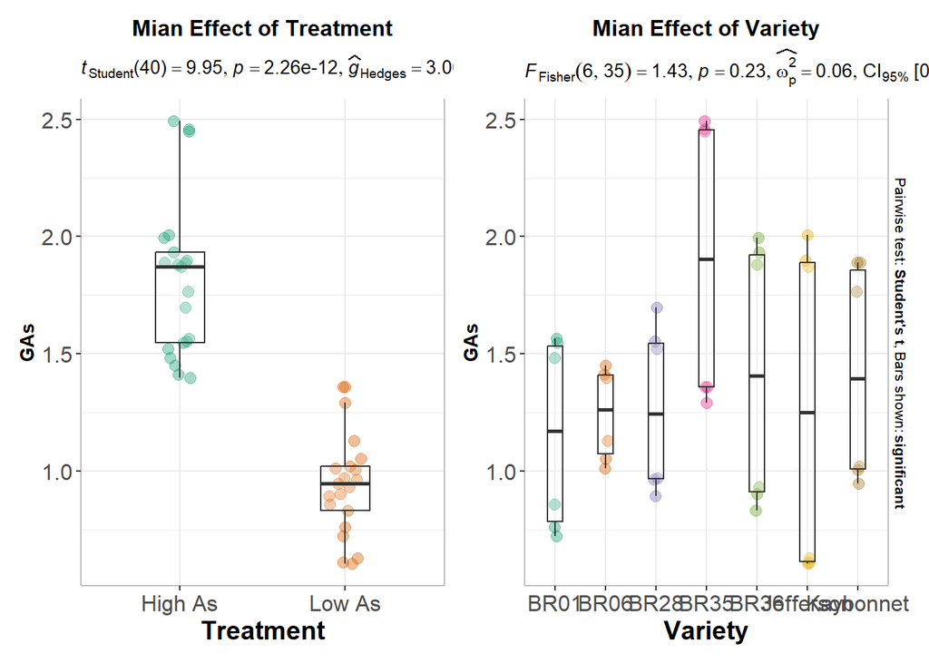

```r
library(patchwork)
p1+p2
```